# Multi-wave HM

JS

Disclaimer (5/8/26): this is still WIP, and some functionality may slightly change.

Load in design, data:

```r
setwd('..')
tmp <- getwd()
source(paste0(tmp, '/plot.R'))
source(paste0(tmp, '/basis.R'))
source(paste0(tmp, '/emulate.R'))
source(paste0(tmp, '/calibrate.R'))
load(paste0(tmp, '/data/systemic_data.RData'))
# Currently need to load ggplot2 explicitly
library(ggplot2)
```

Considering the systemic data (7 flow time series, plus max/min pressure, 5 inputs).

Scaling the design to [0,1] using the provided parameter ranges:

```r
scaled_design <- ScaleInputs(design_sim, parRanges, c(0,1))
dim(scaled_design)
```

```
## [1] 1250    5
```

```r
dim(output_flow)
```

```
## [1]  512    7 1250
```

```r
dim(output_flow) <- c(512*7, 1250)
dim(output_pressure)
```

```
## [1] 1250    2
```

This dataset contains 1250 simulations, with 7 flow outputs each with 512 points, and 2 scalar outputs relating to the maximum and minimum pressure.

For wave 1, we’ll select a subset of 100 points, and then add in others later.

We’ll set the ‘observations’ as the 1250th simulation:

```r
truth <- scaled_design[1250,]
obs_flow <- output_flow[,1250]
obs_pressure <- output_pressure[1250,]
```

Given we have a set of candidate points rather than the ability to select whatever design we like (e.g., using `lhs::maximinLHS` and then simulating the model), we can use functionality from the package to find a space-filling design from the 1249 points (the truth is removed):

```r
set.seed(48219)
designW1 <- NewDesign(scaled_design[1:1249,], n_new = 100)
head(designW1$design)
```

```
##           f2         f3       fs2        fs3      alpha
## 1 0.49068633 0.29349547 0.5775152 0.08613821 0.19204980
## 2 0.04318109 0.36693590 0.5010353 0.49935033 0.04107552
## 3 0.50159615 0.95566883 0.5844009 0.20940159 0.46065722
## 4 0.31672398 0.01354307 0.3427202 0.47221547 0.76795123
## 5 0.14051992 0.14394751 0.5982701 0.55799251 0.45197652
## 6 0.21164014 0.04404844 0.6869699 0.73149846 0.24549872
```

```r
head(designW1$inds)
```

```
## [1]   68 1151 1170 1176  275  279
```

Extracting the model output for these 100 points, and plotting:

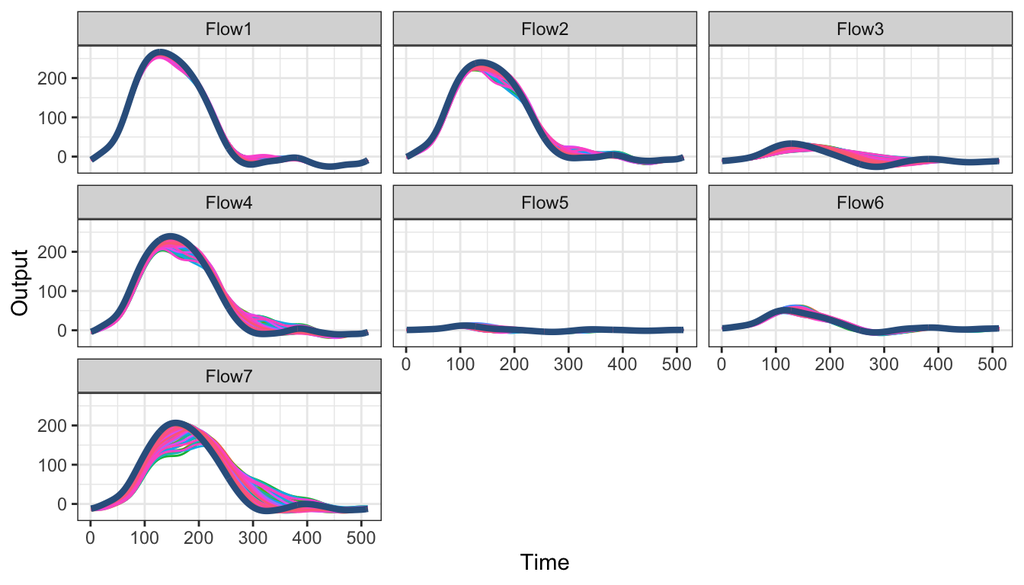

```r
indsW1 <- designW1$inds
designW1 <- designW1$design
flowW1 <- output_flow[,indsW1]
pressureW1 <- output_pressure[indsW1,]
DataBasisW1 <- MakeDataBasis(flowW1)
# Add labels for inputs
DataBasisW1$grid <- data.frame(Time = 1:512,
                               Output = rep(c('Flow1','Flow2','Flow3','Flow4','Flow5','Flow6','Flow7'), each = 512))

# Plotting, with obs overlaid
PlotData(DataBasisW1, Obs = obs_flow)
```

Or plotting pressure:

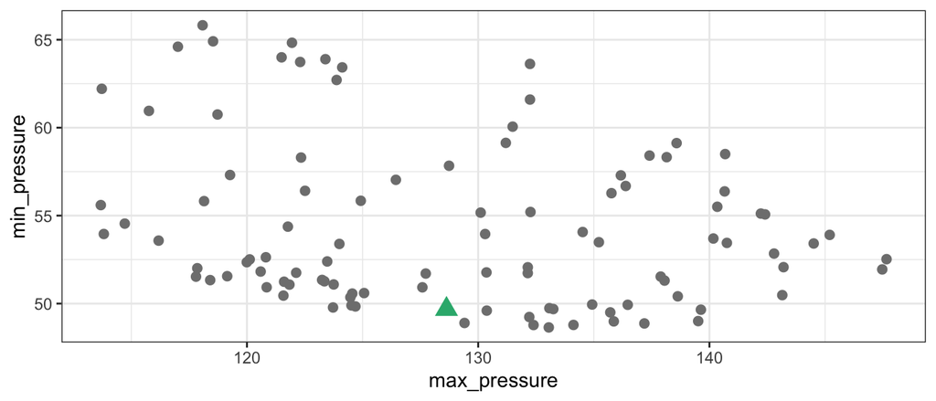

```r
PlotPair(pressureW1, 'max_pressure', 'min_pressure', obs = obs_pressure)
```

Plotting the leading 4 basis vectors:

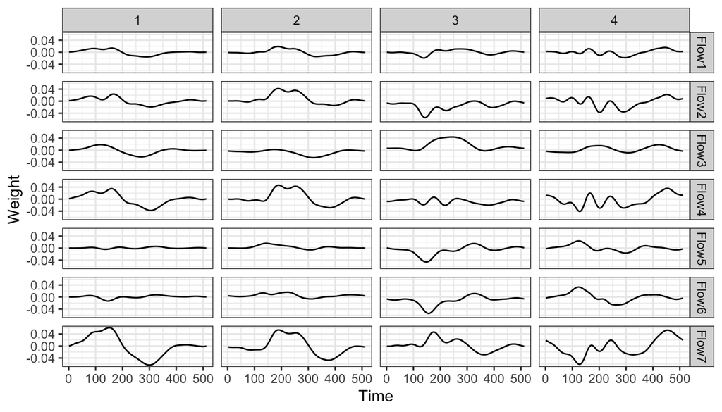

```r
PlotBasis(DataBasisW1, q = 4)
```

By default, splits into the 7 different outputs, although in reality everything’s stacked together into a vector of length 512*7.

## Wave 1

First, let’s constrain space based on the max and min pressure. Emulating these 2 outputs (using all 100 points as training, and considering LOOs rather than prediction over an out-of-sample set):

```r
data_pressureW1 <- data.frame(designW1, pressureW1)
head(data_pressureW1)
```

```
##              f2         f3       fs2        fs3      alpha max_pressure
## 68   0.49068633 0.29349547 0.5775152 0.08613821 0.19204980     131.4901
## 1151 0.04318109 0.36693590 0.5010353 0.49935033 0.04107552     138.1504
## 1170 0.50159615 0.95566883 0.5844009 0.20940159 0.46065722     138.0596
## 1176 0.31672398 0.01354307 0.3427202 0.47221547 0.76795123     115.7609
## 275  0.14051992 0.14394751 0.5982701 0.55799251 0.45197652     128.7400
## 279  0.21164014 0.04404844 0.6869699 0.73149846 0.24549872     124.1200
##      min_pressure
## 68       60.05816
## 1151     58.32301
## 1170     51.30740
## 1176     60.95469
## 275      57.83500
## 279      63.42800
```

```r
inputs <- colnames(designW1)
em_pressureW1 <- FitEmulators(data_pressureW1, input = inputs, output = c('max_pressure', 'min_pressure'))
looW1 <- LeaveOneOut(em_pressureW1, Obs = obs_pressure, by_index = TRUE)
```

If we’re satisfied with the emulators, we can now history match. For each output, we’ll set the observation error variance as 1/4, so that $\pm2$SD corresponds to $\pm1$ pressure:

```r
set.seed(2819)
BigDesign <- lhs::randomLHS(5000,5)
colnames(BigDesign) <- colnames(scaled_design)
hmW1 <- HistoryMatch(em_pressureW1, BigDesign, Obs = obs_pressure, ObsVar = c(1/4, 1/4))
hmW1$NROY
```

```
## [1] 0.0918
```

```r
hmW1$Pass_kth
```

```
## [1] 0.1624 0.4372
```

Perhaps surprisingly, `max_pressure` is the stronger constraint at this stage (16% kept), with 9% satisfying both constraints. Plotting NROY space:

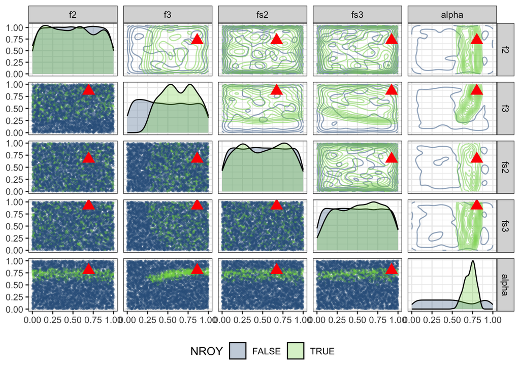

```r
PlotNROY(hmW1$Design, Truth = truth)
```

`alpha` is strongly constrained, and lower values of `f3` have been ruled out, but the other 3 inputs still have fairly uniform densities.

We could now bring in other outputs to attempt to reduce space further, but instead let’s perform another wave using only max/min pressure.

## Wave 2

We need to draw a new design from our set of candidate points (where removed those that were already chosen at wave 1):

```r
CandPointsW2 <- scaled_design[1:1249,]
CandPointsW2 <- CandPointsW2[-indsW1,]
```

We need to find which of these are in the current NROY space:

```r
hmW1_cand <- HistoryMatch(em_pressureW1, CandPointsW2, Obs = obs_pressure, ObsVar = c(1/4, 1/4))
hmW1_cand$NROY
```

```
## [1] 0.09660574
```

```r
CandPointsW2 <- subset(hmW1_cand$Design, NROY1)
dim(CandPointsW2)
```

```
## [1] 111   6
```

There’s only 111 points in the current NROY space. Let’s select 100 of them, and see if we can improve emulation and calibration:

```r
set.seed(48218)
designW2 <- NewDesign(CandPointsW2, n_new = 100)

indsW2 <- designW2$inds
designW2 <- designW2$design

# It's a bit convoluted to get to the corresponding, original indices
indsW2_original <- c(1:1249)[-indsW1][which(hmW1_cand$inNROY)][indsW2]

flowW2 <- output_flow[,indsW2_original]
pressureW2 <- output_pressure[indsW2_original,]
```

Plotting as before, to see whether we’ve reduced the ensemble spread:

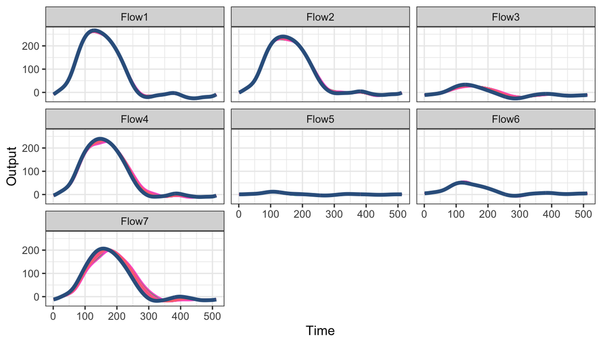

```r
DataBasisW2 <- MakeDataBasis(flowW2)
DataBasisW2$grid <- DataBasisW1$grid
PlotData(DataBasisW2, Obs = obs_flow)
```

We’ve clearly been successful in ruling out simulations far from the observations (wave 2 plotted on same scale as wave 1 to show the reduction towards the observations):

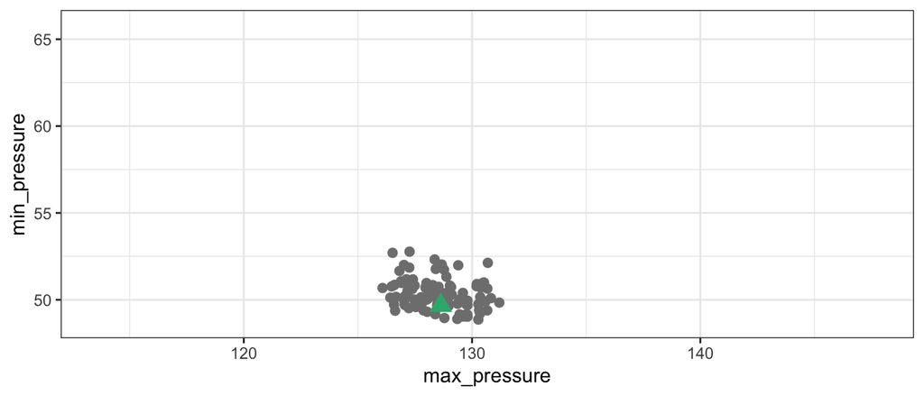

```r
PlotPair(pressureW2, 'max_pressure', 'min_pressure', obs = obs_pressure) +
  xlim(range(pressureW1$max_pressure)) +
  ylim(range(pressureW1$min_pressure))
```

Fitting new emulators:

```r
data_pressureW2 <- data.frame(designW2, pressureW2)
em_pressureW2 <- FitEmulators(data_pressureW2, input = inputs, output = c('max_pressure', 'min_pressure'))
looW2 <- LeaveOneOut(em_pressureW2, Obs = obs_pressure, by_index = TRUE)
```

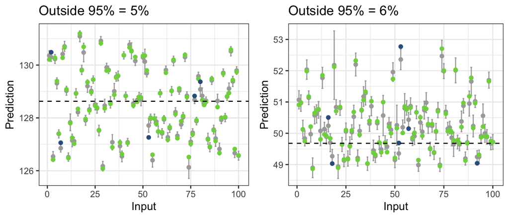

For HM, we can provide the code with the previous output of `HistoryMatch` as a starting point of samples from NROY (we still have to provide `Obs` etc., as we could emulate different outputs at each wave):

```r
hmW2 <- HistoryMatch(em_pressureW2, Obs = obs_pressure, ObsVar = c(1/4, 1/4), PreviousWave = hmW1)
hmW2$NROY
```

```
## [1] 0.0582
```

So we’re now down to 6% of the original space (from 9% after wave 1).

```r
hmW2$Pass_kth
```

```
## [1] 0.7189542 0.8801743
```

We’ve not been able to rule out much more based on `min_pressure`.

Plotting the updated NROY. We can so in 2 ways, as `hmW2$Design` contains all of the 5000 samples, with indicators for `NROY1` and `NROY2`. Plotting NROY2 relative to the original space:

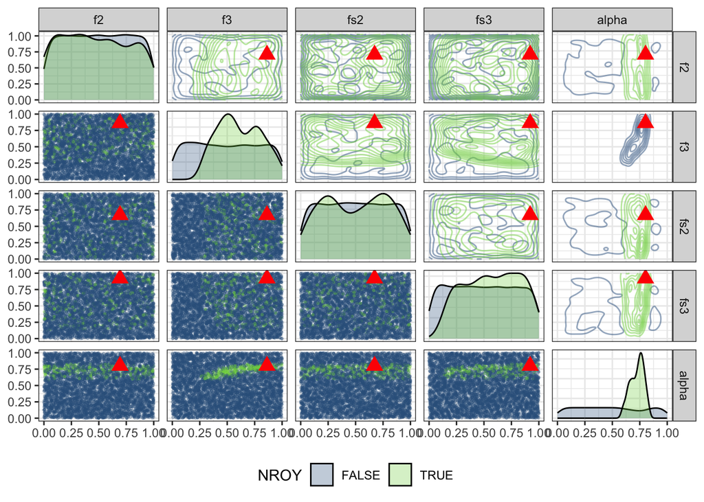

```r
PlotNROY(hmW2$Design, k = 1:5, Truth = truth)
```

Or just considering those that were in NROY at W1:

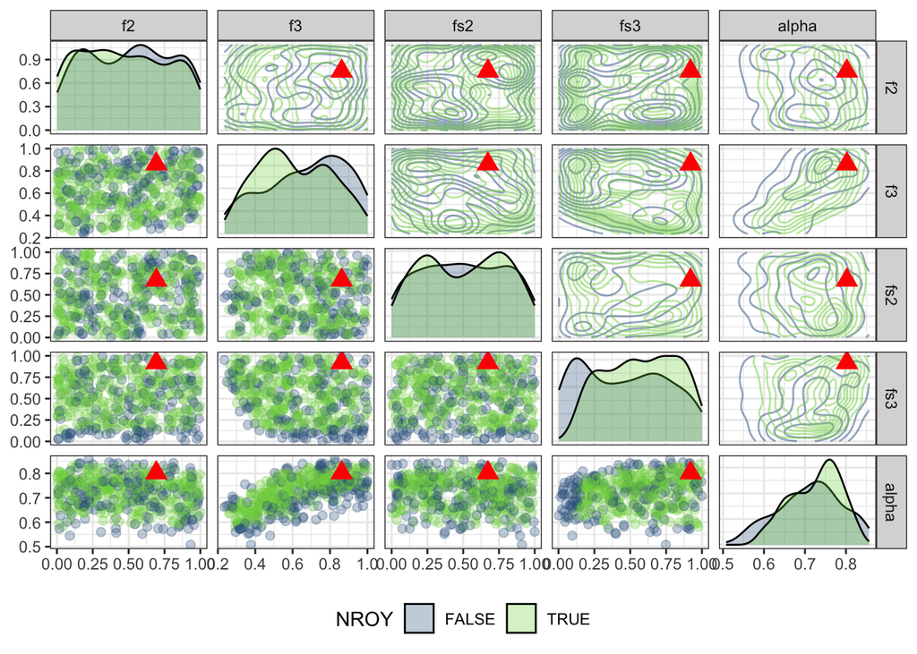

```r
PlotNROY(subset(hmW2$Design, NROY1), k = 1:5, Truth = truth)
```

We’ve ruled out a bit more, mostly around the edges (lower `fs3`, higher `f3`).

We could keep sampling new points from within NROY and continue to refine the emulators, to see if can reduce space further (not done here as restricting to the 1250 pre-prepared simulations).

## Adding previous NROY simulations

Before fitting new emulators, we may wish to add in some of the simulations from wave 1. Sometimes adding all of them might give a better emulator, even those that are far from the observations and NROY space, but usually we want to remove those (e.g., the stationary assumption will hopefully be reasonable in the reduced space that we’ve zoomed in on, but may not be if we include the full parameter space, and result in worse emulation in the regon we actually care about).

In general, we should at least add any simulations from the previous wave that are in NROY: this is definitely useful information about the simulator! Here, there won’t be many, if any, given we’ve ruled out a large percentage of parameter space, and there will likely be little benefit as these outputs are relatively easy to emulate, and we have a reasonable coverage of 5D space. In cases where the input space is higher-dimensional, the simulator is more expensive, or the output harder to emulate, using all (useful) simulations we have available to train emulators is more important.

Let’s check whether any of the wave 1 simulations were in the wave 1 NROY space:

```r
hmW1_design <- HistoryMatch(em_pressureW1, designW1, Obs = obs_pressure, ObsVar = c(1/4, 1/4))
hmW1_design$NROY
```

```
## [1] 0.05
```

```r
which(hmW1_design$inNROY)
```

```
## [1] 37 44 62 66 90
```

We find that 5% of them are.

In some cases, keeping points that are close to but just outside NROY space can also help the emulator (in particular, helping to better define the boundaries). Instead of just keeping everything, we could slightly relax the implausibility cutoff, say to 4, so that we keep points that were ruled out, but that are close to NROY:

```r
hmW1_design <- HistoryMatch(em_pressureW1, designW1, Obs = obs_pressure, ObsVar = c(1/4, 1/4), threshold = 4)
hmW1_design$NROY
```

```
## [1] 0.05
```

```r
which(hmW1_design$inNROY)
```

```
## [1] 37 44 62 66 90
```

In this case, this keeps no extra runs.

Adding these 5 points to the wave 2 design, and refitting emulators and history matching:

```r
data_pressureW2_added <- rbind(data_pressureW2, data_pressureW1[which(hmW1_design$inNROY),])
em_pressureW2_added <- FitEmulators(data_pressureW2_added, input = inputs, output = c('max_pressure', 'min_pressure'))
looW2_added <- LeaveOneOut(em_pressureW2_added, Obs = obs_pressure, by_index = TRUE)
```

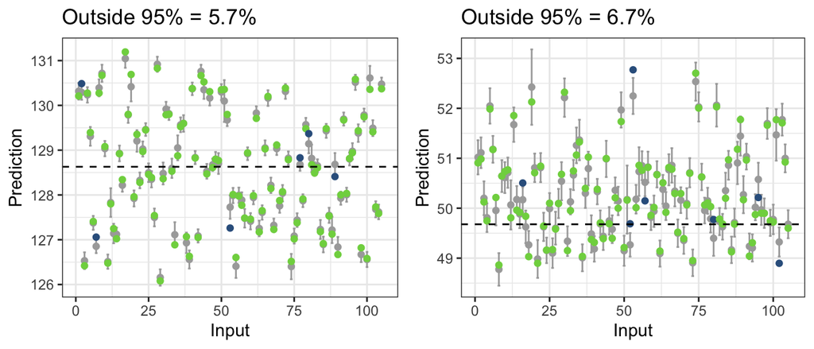

```r
hmW2_added <- HistoryMatch(em_pressureW2_added, Obs = obs_pressure, ObsVar = c(1/4, 1/4), PreviousWave = hmW1)
hmW2_added$NROY
```

```
## [1] 0.0586
```

```r
hmW2_added$Pass_kth
```

```
## [1] 0.7167756 0.8823529
```

For this example, since we had high coverage of simulations in NROY space already, the emulators and hence HM results are little changed by the addition of 5 extra runs.

## Wave 3: adding flow

Instead, it might turn out that we’re restricted things almost as much as is possible based on the pressure: `f2`, `fs2`, and to a lesser extent `fs3`, may not be particularly important for predicting pressure.

Taking the 100 wave 2 runs above, now emulate the flow series:

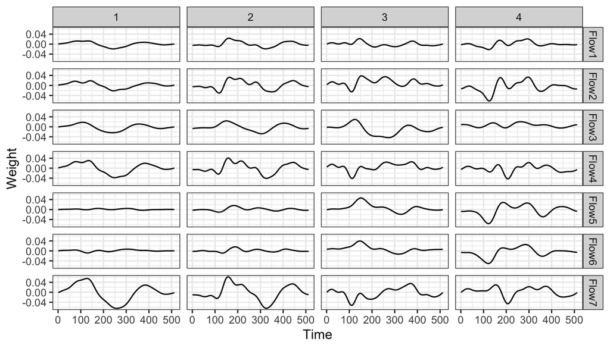

```r
PlotBasis(DataBasisW2, q = 4)
```

Combining the design with coefficients:

```r
data_flowW2 <- GetEmData(designW2, DataBasisW2, q = 6)
```

It’s unclear whether `f2` and `fs2` will be constrained here, e.g., plotting coloured by `C1` there’s not a clean pattern, but there may be in higher dimensions, or for other coefficients:

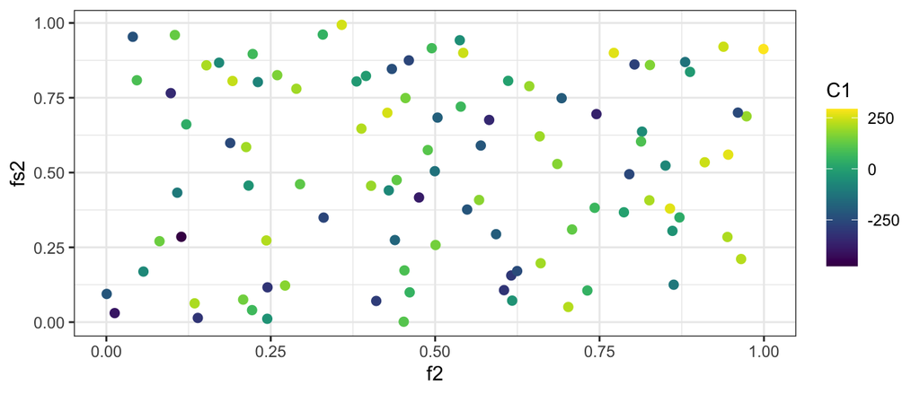

```r
PlotPair(data_flowW2, 'f2', 'fs2', col = 'C1')
```

Emulating leading 6 coefficients (arbitrarily; really should also consider next few in case):

```r
em_flowW2 <- FitEmulators(data_flowW2, input = inputs)
loo_flowW2 <- LeaveOneOut(em_flowW2, by_index = TRUE)
```

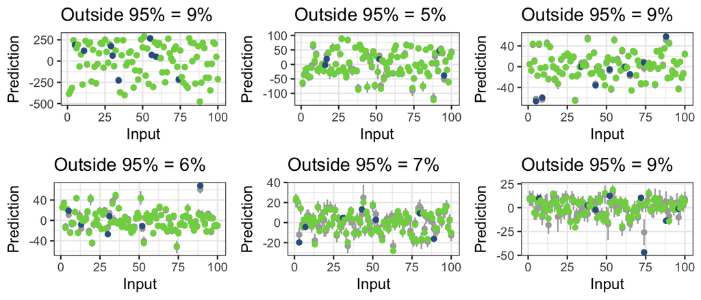

Starting from the W2 NROY space:

```r
hmW3 <- HistoryMatch(em_flowW2, DataBasis = DataBasisW2, Obs = obs_flow, ObsVar = 1/4, PreviousWave = hmW2)
hmW3$NROY
```

```
## [1] 0.0218
```

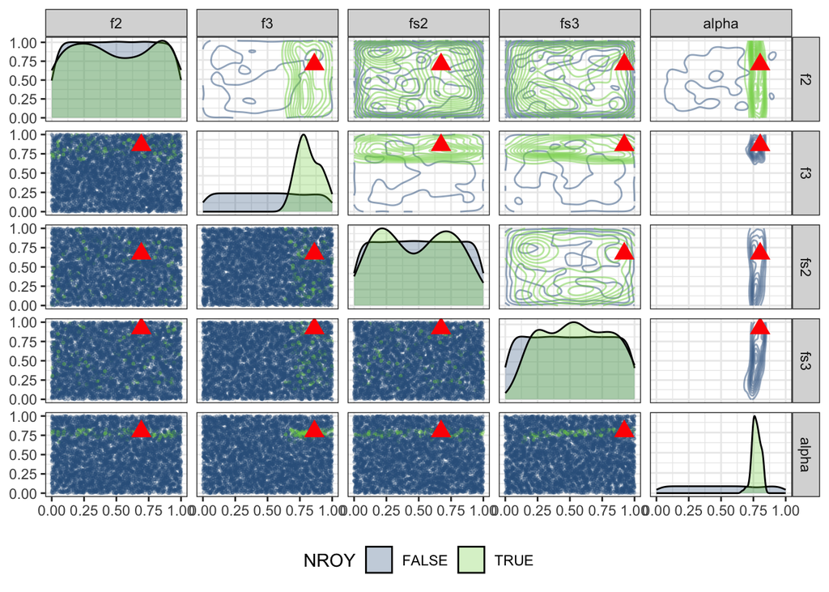

```r
PlotNROY(hmW3$Design, k = 1:5, Truth = truth)
```

Or just considering those that were in NROY at W1:

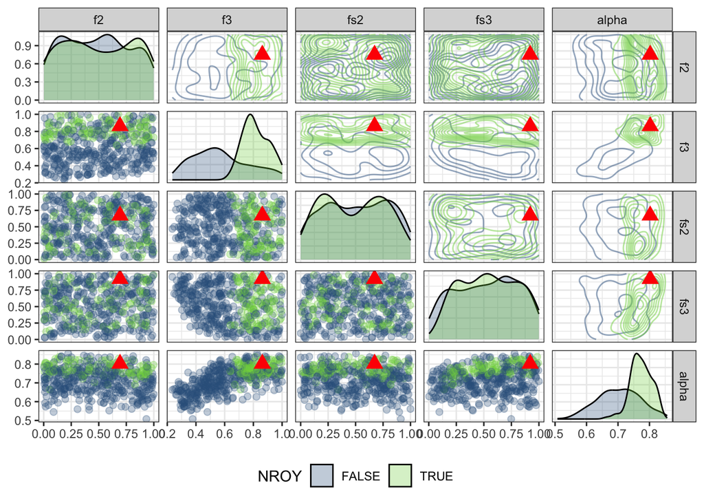

```r
PlotNROY(subset(hmW3$Design, NROY1), k = 1:5, Truth = truth)
```

Still hasn’t had much effect on some of the inputs, but `alpha`, and particularly `f3`, have been constrained even further.

## Plotting some samples

Taking some of the samples and evaluating them with the emulator:

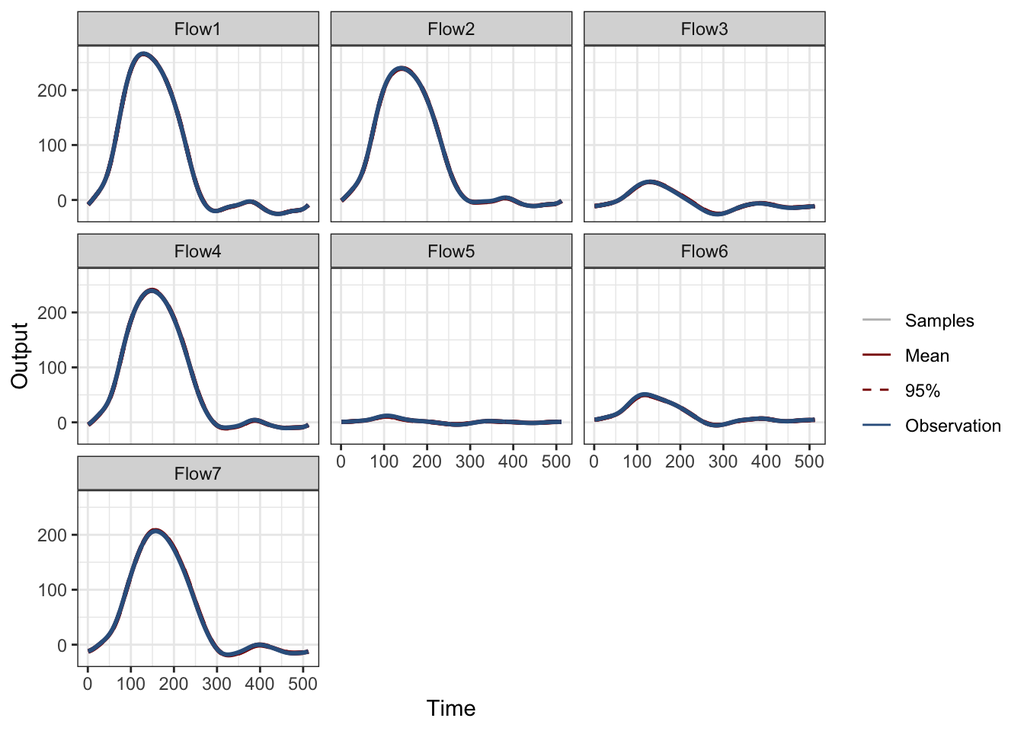

```r
nroyW3 <- subset(hmW3$Design, NROY3)
PlotSamples(DataBasisW2, em_flowW2, design = nroyW3[1,], Obs = obs_flow)
```

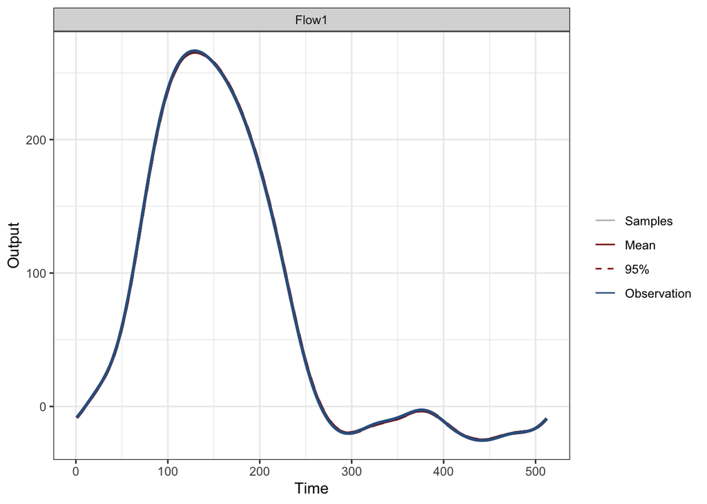

```r
PlotSamples(DataBasisW2, em_flowW2, design = nroyW3[1,], output_inds = which(DataBasisW2$grid$Output == 'Flow1'), Obs = obs_flow)
```

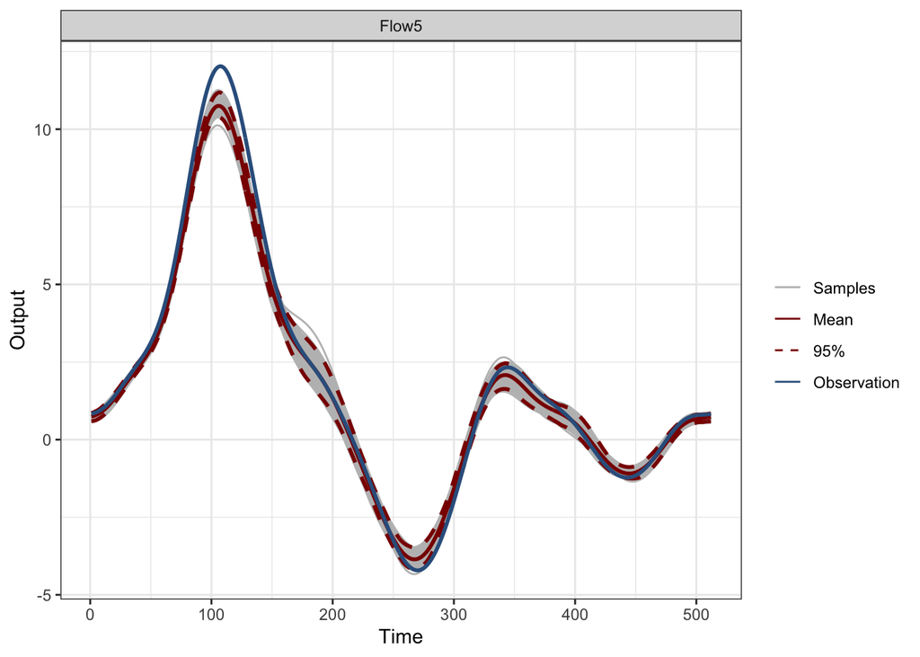

```r
PlotSamples(DataBasisW2, em_flowW2, design = nroyW3[1,], output_inds = which(DataBasisW2$grid$Output == 'Flow5'), Obs = obs_flow)
```

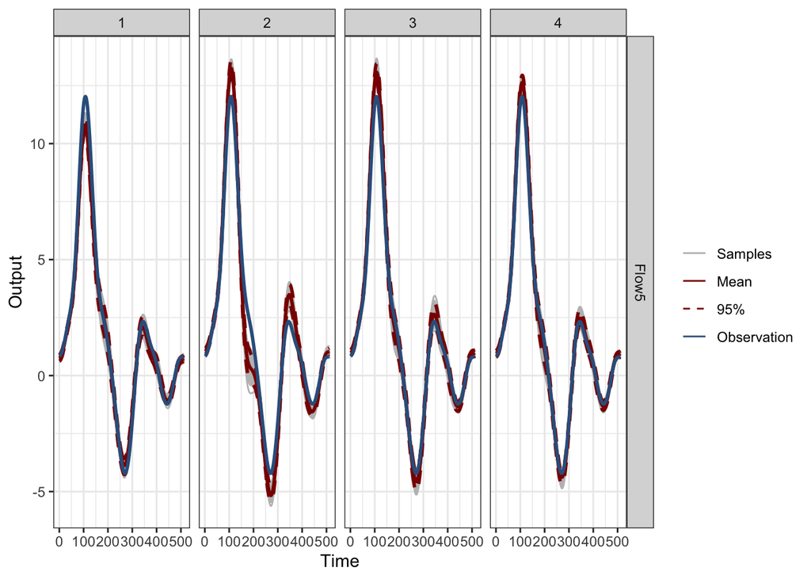

```r
PlotSamples(DataBasisW2, em_flowW2, design = nroyW3[1:4,], output_inds = which(DataBasisW2$grid$Output == 'Flow5'), Obs = obs_flow)
```

Generally predictions from emulator look similar to observations - which they mostly should be, given we’ve ruled out those that don’t (up to emulator uncertainty).

## Evaluating true implausibility/NROY

As an aside, we could consider what the true NROY space looks like. E.g., use all the simulations of the true model that we have available, and use these to define NROY space. There’s no emulation required as the exact output is known, hence emulator variance is zero.

This can be done using the same code as above, but instead of providing emulators, we need to provide the `TrueOutput`. First identifying which inputs lie in the true NROY based on max/min pressure.

If we fail to provide either an emulator or a true output, the code gives an error:

```r
try(hm_pressure_true <- HistoryMatch(design = scaled_design, Obs = obs_pressure, ObsVar = c(1/4, 1/4)))
```

```
## Error in HistoryMatch(design = scaled_design, Obs = obs_pressure, ObsVar = c(1/4,  :
##   Need to provide either an emulator or the true output
```

`TrueOutput` needs to contain columns corresponding to the observations and rows corresponding to the design; here we need to provide a 1250x2 matrix or data frame:

```r
hm_pressure_true <- HistoryMatch(design = scaled_design, Obs = obs_pressure, ObsVar = c(1/4, 1/4), TrueOutput = output_pressure)
hm_pressure_true$NROY
```

```
## [1] 0.0536
```

```r
hm_pressure_true$Pass_kth
```

```
## [1] 0.1096 0.3192
```

So in fact, with the 2 waves of HM above we’d actually got quite close to this true space already.

Verifying that the identified 5% of runs do indeed have true output close to the observations:

```r
summary(output_pressure[hm_pressure_true$inNROY,])
```

```
##   max_pressure    min_pressure
##  Min.   :127.2   Min.   :48.90
##  1st Qu.:127.9   1st Qu.:49.66
##  Median :128.5   Median :50.00
##  Mean   :128.5   Mean   :49.96
##  3rd Qu.:129.2   3rd Qu.:50.35
##  Max.   :129.8   Max.   :51.17
```

Plotting the true NROY space:

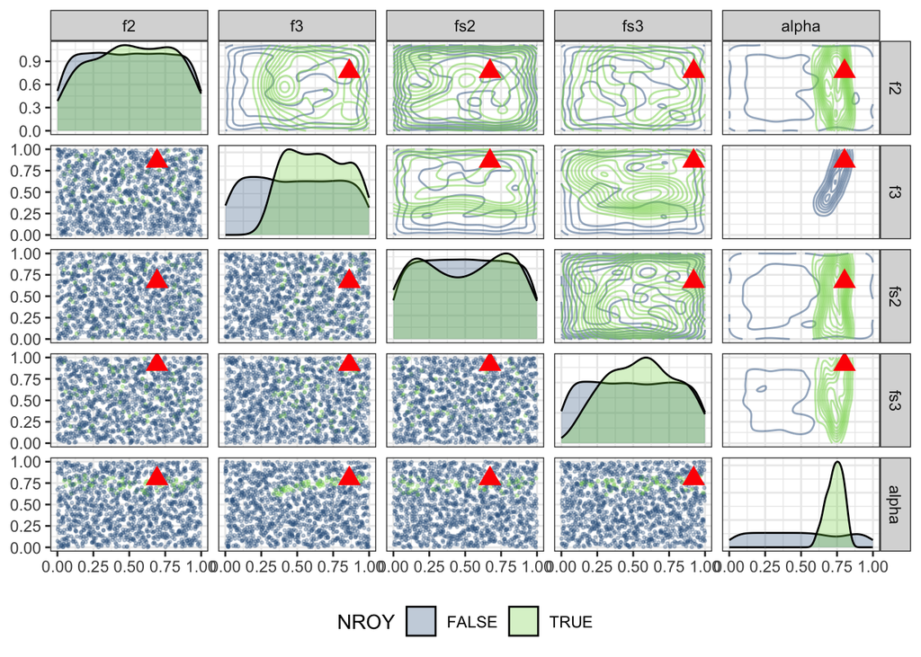

```r
PlotNROY(hm_pressure_true$Design, k = 1:5, Truth = truth)
```

Instead for flow:

```r
hm_flow_true <- HistoryMatch(design = scaled_design, Obs = obs_flow, ObsVar = 1/4, TrueOutput = t(output_flow))
hm_flow_true$NROY
```

```
## [1] 0.004
```

Note: by default, if the observations and true output are at least 50D, the multivariate implausibility is assumed, otherwise the set of 1D implausibilities is calculated. This default behaviour can be overwrriten by setting `Multivariate = TRUE` or `FALSE` as appropriate.

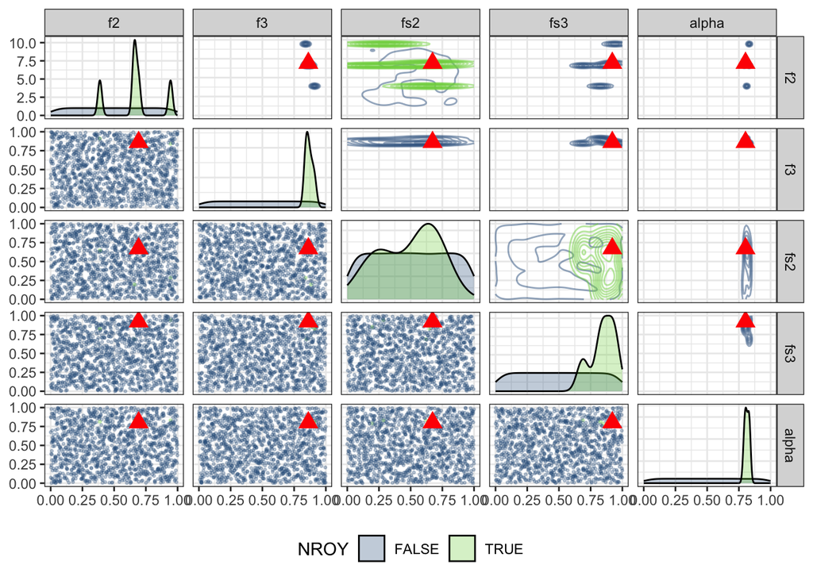

```r
PlotNROY(hm_flow_true$Design, k = 1:5, Truth = truth)
```